# Correlation between books and economic performance

Author

Niclas

Published

May 27, 2024

My dear friend Tobias asked the questions, how the books per capita influence the economic performance of one country. This question is not precise and does not imply any causality, but merely an interesting correlation.

# Getting the data

Before we compute anything, we need to get our hands on some data. We can not say anything about the number of physical books in any country, since nobody is counting them in all households and there are various ways to acquire books. However we can find data about the number of books published in a country within a single year. The website [worldpopulationreview.com](https://worldpopulationreview.com/country-rankings/books-published-per-year-by-country) offers data about some countries in some years. This list is neither complete nor with only recent data. But it’s the best we have.

The World Bank has data for the [population](https://data.worldbank.org/indicator/SP.POP.TOTL?view=chart) by years and the [GDP with Purchasing Power Parity per capita](https://data.worldbank.org/indicator/NY.GDP.PCAP.PP.KD?view=chart). I choose the GDP with Purchasing Power Parity in order to compare different purchasing powers in different countries. The GDP PPP is given in constant 2017 US-Dollar, so it’s already without inflation.

# Visualize the data

We have to link our different data to compare and visualize it. But before we do some data cleaning and compute the number of published books by 100k, in order to standardize it. Since not every country has published data, we only have $104$ data points.

```r
library(tidyverse)

population <- read_csv("~/R/books-vs-gdp/population.csv")
GDP_captia_PPP <- read_csv("~/R/books-vs-gdp/GDP_captia_PPP.csv")
books_published_per_year_by_country_2024 <- read_csv("~/R/books-vs-gdp/books-published-per-year-by-country-2024.csv",
                                                     col_types = cols(BooksPublishedPerYearAdditionalNotes = col_skip()))

population <- population %>%
  select(-where(is.logical)) %>%
  select(-'Country Code', -'Indicator Code', - 'Indicator Name') %>%
  rename("country" = 'Country Name') %>%
  pivot_longer(cols = where(is.numeric), names_to = "year", values_to = "population") %>%
  mutate(year = as.character(year))

GDP_captia_PPP <- GDP_captia_PPP %>%
  select(-where(is.logical)) %>%
  select(-'Country Code', -'Indicator Code', - 'Indicator Name') %>%
  rename("country" = 'Country Name') %>%
  pivot_longer(cols = where(is.numeric), names_to = "year", values_to = "GDP_PPP") %>%
  mutate(year = as.character(year))

books_vs_gdp <- population %>%
  inner_join(GDP_captia_PPP, by = c("country", "year")) %>%
  inner_join(books_published_per_year_by_country_2024, by=c("country" = "country", "year" = "BooksPublishedPerYearDataYear")) %>%
  filter(!is.na(GDP_PPP)) %>%
  rename("books_published" = "BooksPublishedPerYear") %>%
  mutate(books_per_captia = books_published / population * 100000)
```

We will plot a scatter plot to get a first impression:

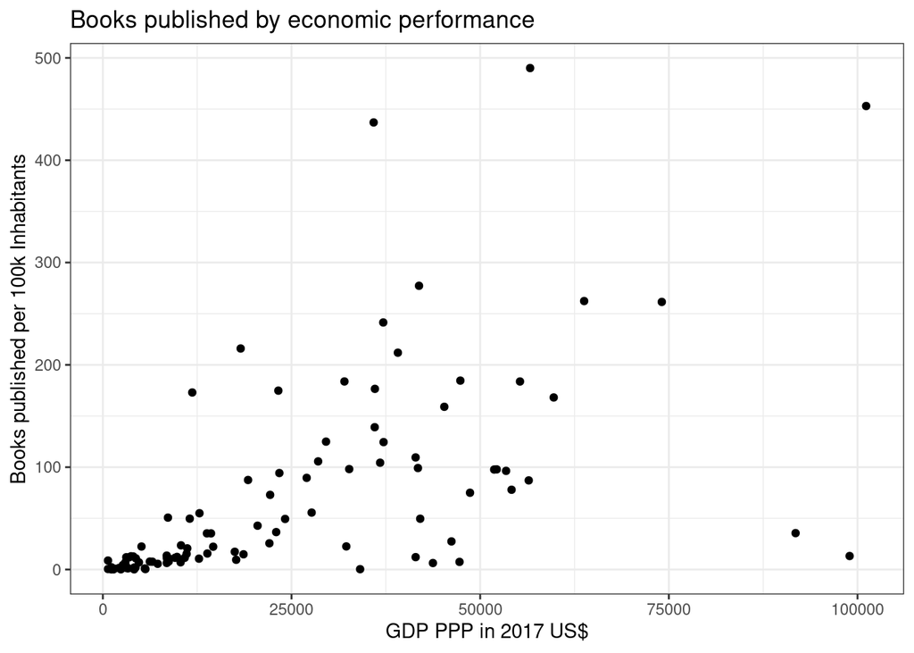

```r
books_vs_gdp %>%
  ggplot() +
  geom_point(aes(GDP_PPP, books_per_captia)) +
  xlab("GDP PPP in 2017 US$") +
  ylab("Books published per 100k Inhabitants") +
  theme_bw() +
  labs(title="Books published by economic performance")
```

We do, like in almost every econometric analysis, a linear regression. However we already see that the assumption of homoscadasticity is violated. If you are asking which countries are on the far right, it’s Luxemburg an UAE.

# The Computation

At first we compute the correlation and test for significance:

```r
cor.test(books_vs_gdp$GDP_PPP, books_vs_gdp$books_per_captia)
```

```
    Pearson's product-moment correlation

data:  books_vs_gdp$GDP_PPP and books_vs_gdp$books_per_captia
t = 7.6681, df = 102, p-value = 1.062e-11
alternative hypothesis: true correlation is not equal to 0
95 percent confidence interval:
 0.4664384 0.7141271
sample estimates:
      cor
0.6047056
```

The correlation of $\rho = 0.605$ is quite high, so we procede to the linear model.

```r
book_model <- lm(GDP_PPP ~ books_per_captia, data = books_vs_gdp )
summary(book_model)
```

```
Call:
lm(formula = GDP_PPP ~ books_per_captia, data = books_vs_gdp)

Residuals:
   Min     1Q Median     3Q    Max
-38866 -11284  -5878   5826  83027

Coefficients:
                 Estimate Std. Error t value Pr(>|t|)
(Intercept)       14096.5     2144.4   6.574 2.12e-09 ***
books_per_captia    138.8       18.1   7.668 1.06e-11 ***
---
Signif. codes:  0 '***' 0.001 '**' 0.01 '*' 0.05 '.' 0.1 ' ' 1

Residual standard error: 17940 on 102 degrees of freedom
Multiple R-squared:  0.3657,    Adjusted R-squared:  0.3594
F-statistic:  58.8 on 1 and 102 DF,  p-value: 1.062e-11
```

This technical output tells us, that one published book by 100k inhabitants contributes $138.8$ US-Dollar to the GDP (PPP) per capita and explains roughly $36\%$ of the variance in our observation.

So, that’s your answer Tobias!